# Quantiles

Author

Luis Francisco Gomez Lopez

Published

June 22, 2023

# 1 What 85% of people actually want

Let $x = (3, 13, 8, 7, 20, 10, 8, 16, 15, 6)$ then order the data, $x$, from lowest to highest $x_{order} = (3, 6, 7, 8, 8, 10, 13, 15, 16, 20)$

Also define the following variables:

- $n$ the size of the data, which for $x$ is 10 because it has 10 data points without eliminating repeated values

Now let calculate the 0.25-quantile (aka first quartile, aka 25% percentile), 0.5-quantile (aka median, aka second quartile, aka 50% percentile) and 0.75-quantile (aka third quartile, aka 75% percentile)

- 0.25-quantile
  - $\lceil Np \rceil = \lceil 10*0.25 \rceil = \rceil = \lceil 2.5 \rceil = 3$. Then find the 3 position in $x_{order}$, which is $7$ and this will be the 0.25-quantile
    - $\lceil Np \rceil$ means the least integer greater than or equal to $Np$. For example $\lceil 2 \rceil = 2$, $\lceil 2.25 \rceil = 3$, $\lceil 2.5 \rceil = 3$, $\lceil 2.75 \rceil = 3$ or $\lceil 3 \rceil = 3$
- 0.5-quantile
  - $\lceil Np \rceil = \lceil 10*0.5 \rceil = \lceil 5 \rceil = 5$. Then find the 5 position in $x_{order}$, which is $8$ and this will be the 0.5-quantile
- 0.75-quantile
  - $\lceil Np \rceil = \lceil 10*0.75 \rceil = \lceil 7.5 \rceil = 8$. Then find the 8 position in $x_{order}$, which is $15$ and this will be the 0.75-quantile

If anyone says that what you learn in this section is wrong just point them out the following reference (Hyndman and Fan 1996, Definition 1) and the following R and Python code:

- R code:

```r
quantile(x = c(3, 13, 8, 7, 20, 10, 8, 16, 15, 6),
         probs = c(0.25, 0.5, 0.75),
         na.rm = FALSE,
         names = TRUE,
         type = 1,
         digits = 7)
```

```
25% 50% 75%
  7   8  15
```

- Python code:

```python
import numpy as np

np.quantile([3, 13, 8, 7, 20, 10, 8, 16, 15, 6],
            [0.25, 0.5, 0.75],
            axis=None,
            out=None,
            overwrite_input=False,
            method='inverted_cdf',
            keepdims=False,
            interpolation=None)
```

```
array([ 7,  8, 15])
```

# 2 What 15% of people actually want

## 2.1 Quantile of a distribution

**Definition 1 (p-quantile of a distribution $F$ (Florescu and Tudor 2014, p 178-179, Definition 6.1))** If $F$ is a distribution function. Let $p \in (0,1)$ be a constant. Define:

$$Q(p) = \inf\{x:F(x) \geq p\}$$
where $Q(p)$ is the p-quantile of the distribution $F$ and $\inf$ is the infimum of the set $\{x:F(x) \geq p\}$

### 2.1.1 Quantile of a normal standard distribution

If we assume $F$ is the standard normal distribution function and we apply Definition 1 to find the $x$ associated to $p$ we need to solve the following problem:

$$p = \int_{-\infty}^{x} \frac{1}{\sqrt{2\pi}}e^{-\frac{z^2}{2}}\,dz \equiv \Phi(x)$$
We need first to calculate $\Phi(x)$:

- Let define $t = \frac{z}{\sqrt{2}}$ so we have that:
  - $z = \sqrt{2}t$
  - $\frac{z^2}{2} = t^2$
  - $\,dz = \sqrt{2}\,dt$

$$\begin{split}
\Phi(x) & = \frac{1}{\sqrt{2\pi}} \int_{-\infty}^{x} e^{-\frac{z^2}{2}}\,dz \\
& = \frac{\sqrt{2}}{\sqrt{2\pi}} \int_{-\infty}^{\frac{x}{\sqrt{2}}} e^{-t^2}\,dt \\
& = \frac{1}{\sqrt{\pi}} \biggl[ \int_{-\infty}^{0} e^{-t^2}\,dt + \int_{0}^{\frac{x}{\sqrt{2}}} e^{-t^2}\,dt \biggr] \\
& = \frac{1}{\sqrt{\pi}} \biggl[ \frac{\sqrt{\pi}}{2} + \int_{0}^{\frac{x}{\sqrt{2}}} e^{-t^2}\,dt \biggr] \\
& = \frac{1}{2} \biggl[ 1 + \frac{2}{\sqrt{\pi}} \int_{0}^{\frac{x}{\sqrt{2}}} e^{-t^2}\,dt \biggr] \\
& = \frac{1}{2} \biggl[ 1 + \text{erf} \biggl( \frac{x}{\sqrt{2}} \biggr) \biggr] \\
\end{split}$$

For more information about $\text{erf}$ check out (Oldham, Myland, and Spanier 2008). What we need to know is that:

- $\text{erf} \biggl( \frac{x}{\sqrt{2}} \biggr)$ can not be represented using elementary functions taking into account the work by Joseph Liouville (1809 - 1882) (See Liouville’s theorem (differential algebra))
- The inverse function of $\text{erf}$ exists, $\text{erf}^{-1}$ and $\text{erf}^{-1}(\text{erf}(z)) = z$ for $z \in \mathbb{R}$ so we restrict the domain of $\text{erf}$ to $\mathbb{R}$
- The range of $\text{erf}$ is $(-1, 1)$ so the domain of $\text{erf}^{-1}$ is also $(-1, 1)$
- Because $p \in (0,1)$ we have that $2p - 1 \in (-1,1)$

Also to understand more about $\text{erf}$ and $\text{erf}^{-1}$ we can plot them using the R packages `ggplot2`, `pracma` and `latex2exp`:

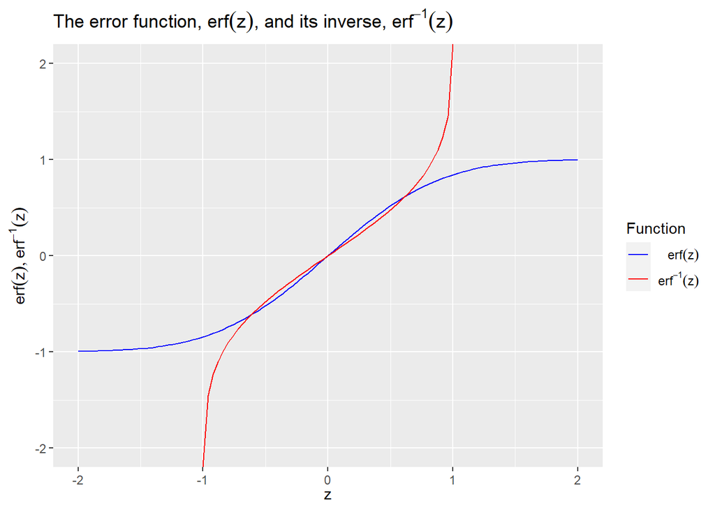

```r
library(ggplot2)
library(pracma)
library(latex2exp)

ggplot() +
  geom_function(aes(colour = 'erf'), fun = erf) +
  geom_function(aes(colour = 'erfinv'), fun = erfinv) +
  scale_x_continuous(limits = c(-2, 2)) +
  scale_y_continuous(limits = c(-2, 2)) +
  scale_color_manual(labels = c(TeX(input = r'($\textrm{erf}(z)$)'),
                                TeX(input = r'($\textrm{erf}^{-1}(z)$)')),
                     values = c("blue", "red")) +
  labs(x = TeX(input = r'($z$)'),
       y = TeX(input =r'($\textrm{erf}(z)\textrm{, }\textrm{erf}^{-1}(z)$)'),
       colour = "Function",
       title = TeX(input = r'(\textrm{The error function, }$\textrm{erf}(z)$\textrm{, and its inverse, }$\textrm{erf}^{-1}(z)$)'))
```

Therefore we have that:

$$\begin{split}
p & = \Phi(x) \\
p & = \frac{1}{2} \biggl[ 1 + \text{erf} \biggl( \frac{x}{\sqrt{2}} \biggr) \biggr] \\
\sqrt{2} \text{erf}^{-1}(2p - 1) & = x \\
\end{split}$$

See:

- https://en.wikipedia.org/wiki/Error_function#Approximation_with_elementary_functions
- https://en.wikipedia.org/wiki/Closed-form_expression
- https://stats.libretexts.org/Bookshelves/Probability_Theory/Probability_Mathematical_Statistics_and_Stochastic_Processes_(Siegrist)/03%3A_Distributions/3.06%3A_Distribution_and_Quantile_Functions
- https://en.wikipedia.org/wiki/Normal_distribution#Quantile_function

## 2.2 Sample quantile

- Inspect the function

```r
quantile
```

```
function (x, ...)
UseMethod("quantile")
<bytecode: 0x0000027db4fe0ba8>
<environment: namespace:stats>
```

- Inspect the methods

```r
methods(quantile)
```

```
[1] quantile.default*    quantile.ecdf*       quantile.POSIXt*
[4] quantile.quosure*    quantile.vctrs_vctr*
see '?methods' for accessing help and source code
```

- Inspect the code for `quantile.default*`

```r
# Also you can use getAnywhere(quantile.default) if you
# don't know the package
stats:::quantile.default
```

```
function (x, probs = seq(0, 1, 0.25), na.rm = FALSE, names = TRUE,
    type = 7, digits = 7, ...)
{
    if (is.factor(x)) {
        if (is.ordered(x)) {
            if (!any(type == c(1L, 3L)))
                stop("'type' must be 1 or 3 for ordered factors")
        }
        else stop("(unordered) factors are not allowed")
        lx <- levels(x)
        x <- as.integer(x)
    }
    else {
        if (is.null(x))
            x <- numeric()
        lx <- NULL
    }
    if (na.rm)
        x <- x[!is.na(x)]
    else if (anyNA(x))
        stop("missing values and NaN's not allowed if 'na.rm' is FALSE")
    eps <- 100 * .Machine$double.eps
    if (any((p.ok <- !is.na(probs)) & (probs < -eps | probs >
        1 + eps)))
        stop("'probs' outside [0,1]")
    n <- length(x)
    probs <- pmax(0, pmin(1, probs))
    np <- length(probs)
    {
        if (type == 7) {
            index <- 1 + max(n - 1, 0) * probs
            lo <- floor(index)
            hi <- ceiling(index)
            x <- sort(x, partial = if (n == 0)
                numeric()
            else unique(c(lo, hi)[p.ok]))
            qs <- x[lo]
            i <- which(!p.ok | (index > lo & x[hi] != qs))
            h <- (index - lo)[i]
            qs[i] <- (1 - h) * qs[i] + h * x[hi[i]]
```

[output cut: 37 more lines]

```
                  3L])[other]
        }
    }
    qs[!p.ok] <- probs[!p.ok]
    if (is.character(lx))
        qs <- factor(qs, levels = seq_along(lx), labels = lx,
            ordered = TRUE)
    if (names && np > 0L) {
        stopifnot(is.numeric(digits), digits >= 1)
        names(qs) <- format_perc(probs, digits = digits)
    }
    qs
}
<bytecode: 0x0000027db7b89a30>
<environment: namespace:stats>
```

## 2.3 QQ plot

A QQ plot, short for quantile-quantile plot, is a graphical tool used to assess whether a dataset follows a particular theoretical distribution, such as the normal distribution. It compares the quantiles of the observed data against the quantiles of a specified theoretical distribution.

You build a QQ plot in the following way:

- First we create some data where we are going to obtain it from a poisson probability mass function with $\lambda = 4$

```r
set.seed(seed = 1234)
sample_data <- rpois(n = 20, lambda = 4)
sample_data
```

```
 [1] 2 4 4 4 6 5 0 2 5 4 5 4 3 7 3 6 3 3 2 2
```

- Then we need to sort the data in ascending order:

```r
sample_data_sort <- sort(x = sample_data, decreasing = FALSE)
sample_data_sort
```

```
 [1] 0 2 2 2 2 3 3 3 3 4 4 4 4 4 5 5 5 6 6 7
```

- Now in the case of R it uses the `ppoints` function:

```r
ppoints
```

```
function (n, a = if (n <= 10) 3/8 else 1/2)
{
    if (length(n) > 1L)
        n <- length(n)
    if (n > 0)
        (1L:n - a)/(n + 1 - 2 * a)
    else numeric()
}
<bytecode: 0x0000027dca979800>
<environment: namespace:stats>
```

So we have the following formula for $j = 1, \ldots, n$:

$$a = \begin{cases}
\frac{3}{8} & \text{ if } & n \leq 10 \\
\frac{1}{2} & \text{ if } & n > 10
\end{cases}$$

$$quantile_j = \frac{j - a}{n + 1 - 2a}$$
In the case of $n > 10$ we have that $quantile_j = \frac{j - \frac{1}{2}}{n + 1 - 2\frac{1}{2}} = \frac{j - \frac{1}{2}}{n}$ where a **continuity correction** is applied. This correction is applied when you want to use a continuous distribution to approximate a discrete distribution.

The literature about **continuity correction** according to `?ppoints` is motivated by (Blom 1958)

Therefore we can calculate the QQ-plot in the following way:

```r
qq_plot_data <- tibble(sample_data_sort = sample_data_sort,
                       sample_quantile = ppoints(n = length(sample_data_sort)))
```

Now we need to add the standard normal distribution quantiles:

```r
qq_plot_data <- qq_plot_data |>
  mutate(standard_normal_quantiles = qnorm(p = sample_quantile, mean = 0, sd = 1))
```

Then we create the QQ plot:

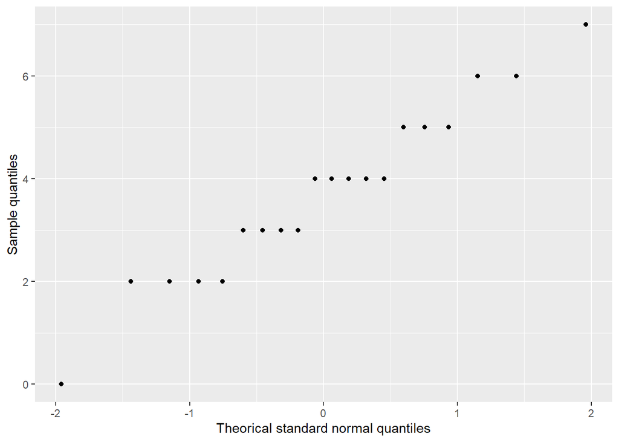

```r
qq_plot_data |>
  ggplot() +
  geom_point(aes(x = standard_normal_quantiles,
                 y = sample_data_sort)) +
  labs(x = 'Theorical standard normal quantiles',
       y = 'Sample quantiles')
```

## 3 References

Blom, Gunnar. 1958. *Statistical Estimates and Transformed Beta-Variables*. Wiley.

Florescu, Ionuţ, and Ciprian A. Tudor. 2014. *Handbook of Probability*. Wiley Handbooks in Applied Statistics. Hoboken, NJ: Wiley.

Hyndman, Rob J., and Yanan Fan. 1996. “Sample Quantiles in Statistical Packages.” *The American Statistician* 50 (4): 361. https://doi.org/10.2307/2684934.

Oldham, Keith B., Jan C. Myland, and Jerome Spanier. 2008. “The Error Function Erf(x) and Its Complement Erfc(x).” In *An Atlas of Functions*, 405–15. New York, NY: Springer US. https://doi.org/10.1007/978-0-387-48807-3_41.